# Paramètrage de la box internet

Pour manipuler l’interface de la livebox Orange, j’ai modifié des paramètres.

## Le DHCP

J’ai mis une plage spécifique d’attribution d’adresse IP.

Le pool est de 192.168.10.1 à 10.100

L’adresse de la box est mis en 192.168.10.254 au lieu de 192.168.0.1

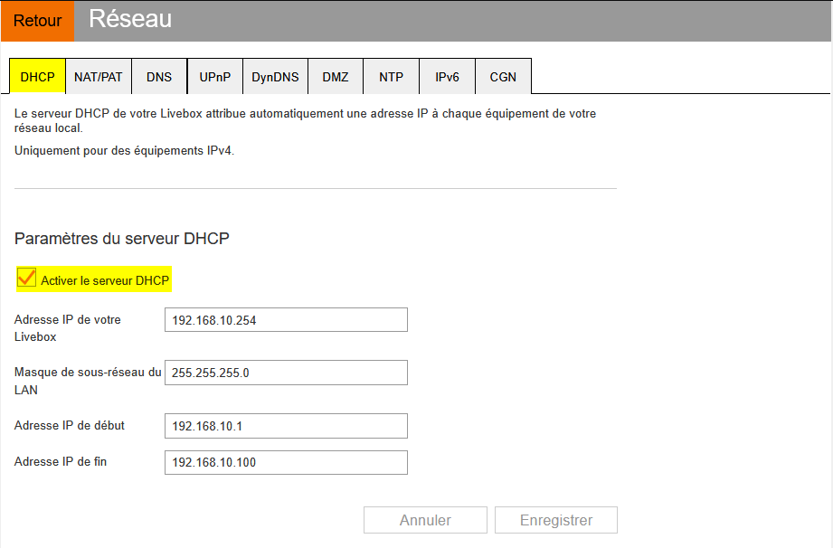

La seconde étape est la fixation de l’adresse IP pour un ordinateur utilisé comme serveur. Dans la section baux DHCP statique, l’adresse est devenue 192.168.10.100

La box internet me propose de mettre mon ordinateur en IP fixe.

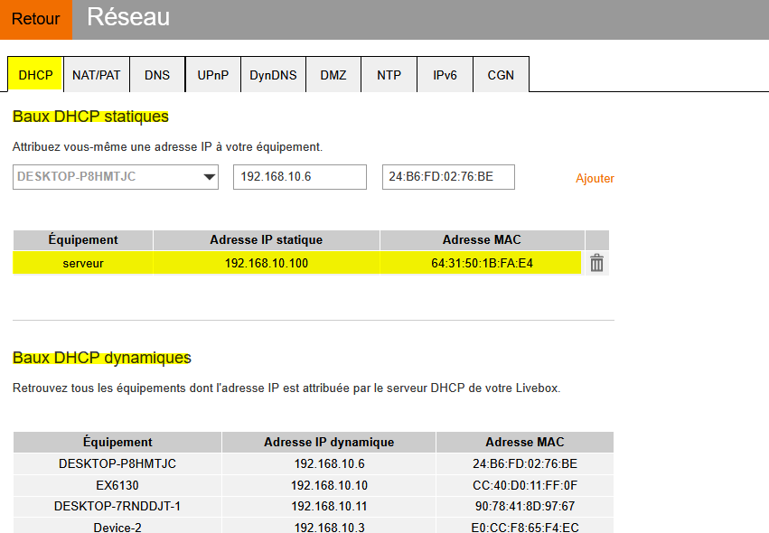

Les baux DHCP dynamique listent tous les appareils avec une adresse déjà connus.

## DNS

Dans l’onglet DNS, le serveur a été nommé **serveur**.

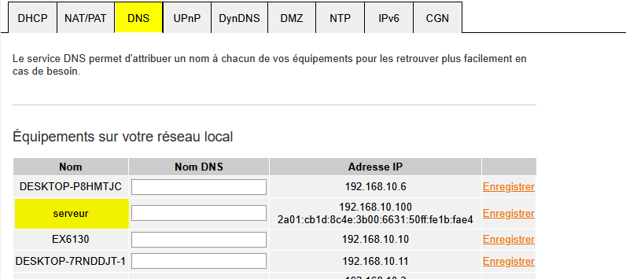

## NAT/PAT

Pour faire un essai, j’avais mis en place un serveur web et ouvert le port 443 pour un accès à internet d’un site test. Dans l’onglet NAT/PAT, une règle permettait de réaliser cela. J’aurai pu le faire aussi avec dynDNS. Je n’ai pas essayé de faire le tet avec un serveur FTP.

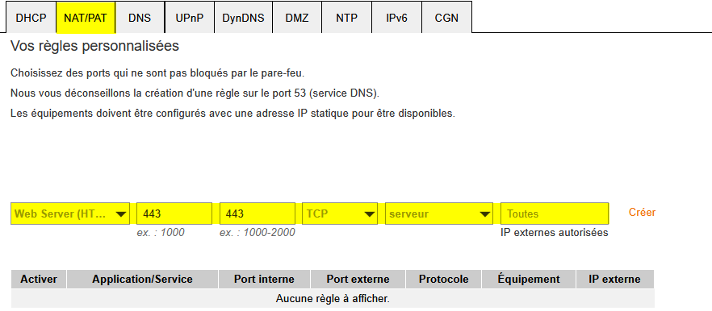

## Bandes wifi

J’ai séparé les bandes 2.4GHz, 5GHz et le wifi invité. Dans le menu **wifi Livebox**, les noms sont personnalisés.

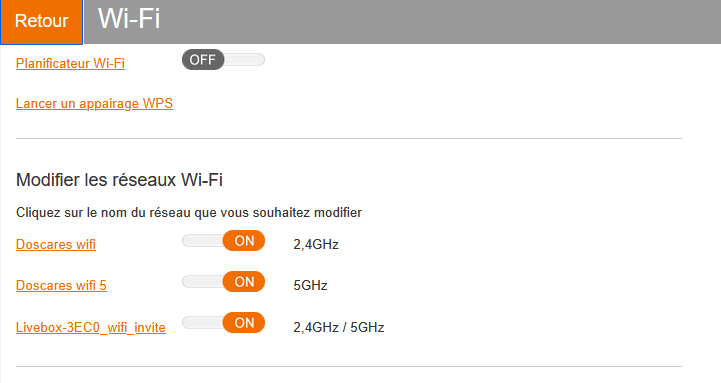

Puis en cliquant sur chaque réseau, il est possible de modifier le nom et le mot de passe. Surtout utile sur le wifi invité afin d’éviter aux personnes de passage les 18 caractères à taper de la clé d’origine.

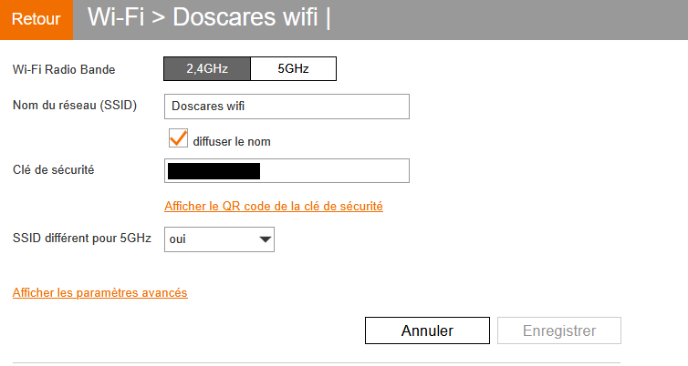